# Clase Práctica 1: Confiabilidad estructuras unidimensionales

HENC

2023-10-03

```r
library(MplusAutomation)
library(data.table)
library(dplyr)
```

# Cargamos los datos

Para cargar los datos con el nombre `Sim_data_1_1.dat` vamos a utilizar la función `fread()` del paquete `data.table`. Se recomienda guardar este archivo en la misma carpeta en la que se ubica la sintaxis de R. De otra manera se tendría que especificar la ruta al folder en el que se encuentren los datos.

Los datos los vamos a guardar en el objeto llamado `D`. Por eso la función `fread()` asigna con `<-` sus resultados al objeto `D`.

**Recuerde que R-software trabaja con objetos y es buena idea utilizarlos siempre que sea posible**

```r
D<-fread("Sim_data_1_1.dat")
```

Para explorar los datos (guardados en el objeto `D`) es posible utilizar diferentes funciones. Por ejemplo, para ver las variables que contiene la base de datos guardados en `D`. Por ejemplo, podemos utilizar la función `names()`.

```r
names(D)
```

```
##  [1] "V1"  "V2"  "V3"  "V4"  "V5"  "V6"  "V7"  "V8"  "V9"  "V10" "V11" "V12"
## [13] "V13" "V14" "V15" "V16" "V17" "V18" "V19" "V20"
```

También podemos utilizar la función `str()`. Esta función nos permite explorar las propiedades de cada una de las variables.

```r
str(D)
```

```
## Classes 'data.table' and 'data.frame':   10000 obs. of  20 variables:
##  $ V1 : num  0 0 0 0 0 0 0 0 0 0 ...
##  $ V2 : num  0 0 0 0 0 0 0 0 1 0 ...
##  $ V3 : num  0 0 0 0 0 0 0 0 1 0 ...
##  $ V4 : num  0 0 0 0 0 0 0 0 1 0 ...
##  $ V5 : num  0 0 0 0 0 0 0 0 1 0 ...
##  $ V6 : num  0 0 0 0 0 0 0 0 1 0 ...
##  $ V7 : num  0 0 0 0 0 0 0 0 0 0 ...
##  $ V8 : num  1 0 0 0 0 0 0 1 0 0 ...
##  $ V9 : num  0 0 0 0 0 0 0 0 0 0 ...
##  $ V10: num  0 0 0 0 0 0 0 0 1 0 ...
##  $ V11: num  0 1 0 0 0 0 0 0 1 0 ...
##  $ V12: num  0 0 0 0 0 0 0 0 1 0 ...
##  $ V13: num  0 0 0 0 0 0 0 0 1 0 ...
##  $ V14: num  0 0 0 0 0 0 0 0 1 0 ...
##  $ V15: num  0 0 0 0 0 0 0 0 0 0 ...
##  $ V16: num  4.283 6.36 4.252 6.265 -0.532 ...
##  $ V17: num  2.91 2.93 5.95 8.6 2.69 ...
##  $ V18: num  1.36 8.442 5.035 2.629 -0.763 ...
##  $ V19: num  4.36 3.41 3.29 5.32 5.88 ...
##  $ V20: num  1.49 1.183 0.987 -0.423 0.338 ...
##  - attr(*, ".internal.selfref")=<externalptr>
```

Por supuesto que hay distintos procedimientos que se podrían utilizar para analizar las variables de la base de datos. Desde tabulados básicos hasta algún modelo de SEM. Por ejemplo, podemos calcular la media de los primeros nuevos indicadores. La función `colMeans()` calcula el promedio de las columnas que se indican en la función de la forma `D[,1:9]`. Esto es de las primeras nueve variables de la base de datos. Se multiplica por 100 para obtener proporciones.

```r
colMeans(D[,1:9])*100
```

```
##    V1    V2    V3    V4    V5    V6    V7    V8    V9
##  7.49  2.43  5.65  4.64  6.30  3.36 12.87 16.12 14.72
```

También podemos obtener la matriz de correlación de las primeras nueve variables con la función `cor()`. Esta función es bastante sencilla. Sin embargo, hay funciones más potentes que permiten hacer procesamientos más complejos como distintos tipos de correlación u obtener un correlograma.

```r
cor(D[,1:9])
```

```
##             V1           V2           V3           V4          V5           V6
## V1 1.000000000  0.483075037  0.600044289  0.591013657  0.58449269  0.404428105
## V2 0.483075037  1.000000000  0.509883158  0.551799648  0.48298669  0.424683761
## V3 0.600044289  0.509883158  1.000000000  0.586378851  0.56403765  0.415856019
## V4 0.591013657  0.551799648  0.586378851  1.000000000  0.55719730  0.420556414
## V5 0.584492686  0.482986689  0.564037646  0.557197300  1.00000000  0.406183000
## V6 0.404428105  0.424683761  0.415856019  0.420556414  0.40618300  1.000000000
## V7 0.025643137  0.014983548  0.022355712  0.025955952  0.01587873  0.012854683
## V8 0.015766733  0.008527667  0.004619561  0.013191147  0.01057071  0.008808764
## V9 0.000801169 -0.012408641 -0.023431718 -0.008454269 -0.01014834 -0.013249628
##              V7            V8            V9
## V1  0.025643137  0.0157667327  0.0008011690
## V2  0.014983548  0.0085276668 -0.0124086409
## V3  0.022355712  0.0046195608 -0.0234317176
## V4  0.025955952  0.0131911470 -0.0084542694
## V5  0.015878728  0.0105707105 -0.0101483411
## V6  0.012854683  0.0088087642 -0.0132496282
## V7  1.000000000 -0.0084982494 -0.0121761224
## V8 -0.008498249  1.0000000000 -0.0002198284
## V9 -0.012176122 -0.0002198284  1.0000000000
```

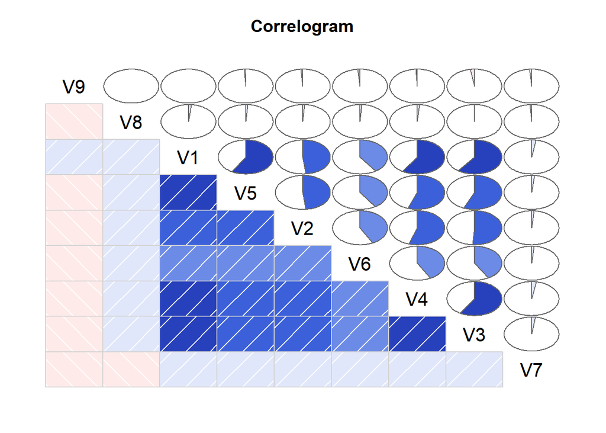

```r
#install.packages("corrgram")
library(corrgram)

corrgram(D[,1:9],
         order = TRUE,
         upper.panel = panel.pie,
         lower.panel = panel.shade,
         text.panel = panel.txt,
         main = "Correlogram")
```

# Análisis de confiabilidad

A continuación se realizan cuatro análisis de confiabilidad a partir de modelos de SEM. Se trata de cuatro modelos distintos de medición a partir de variables categóricas. Piense en estos modelos como casos competitivos de un mismo propósito de medición.

Existen tres preguntas centrales respecto a este modelo:

1. ¿Se sostiene la estructura del modelo dados los datos?
2. ¿Todos los indicadores tienen errores aceptables de medición?
3. ¿Cuál es la confiabilidad de los puntajes?

Considere que el flujo de trabajo en SEM consiste en los siguientes pasos:

1. Especificación del modelo estructural
2. Identificación del modelo estructural
3. Estimación del modelo con el paquete `lavaan()`.
4. Evaluación del ajuste global del modelo
5. Evaluación de las cargas factoriales y el error puntual de medición
6. Estimación de la confiabilidad con $\omega$
7. Interpretación

# Modelo 1

El primer modelo propone una estructura unidimensional de nueve indicadores (V1 a V9). Lo primero que vamos a hacer es cargar el paquete `lavaan` con la función `library()`.

```r
library(lavaan)
```

## Especificación

La especificación del modelo se realiza de la siguiente manera. Primero se asigna un nombre a la variable latente. En este caso “f”. Posteriormente se especifica la estructura. Dado que se trata de un modelo unidimensional, basta con incluir a las variables del lado derecho de la ecuación. Es importante notar que la ecuación es determinística de izquierda a derecha. Es decir, es la “f” la que explica la variabilidad de los nueve indicadores. La clave de esta relación se encuentra especificada “=~”. Esta especificación se guarda en el objeto `mod.1`.

```r
mod.1<-'f =~ V1 + V2 + V3 + V4 + V5 + V6 + V7 + V8 + V9'
```

## Estimación

Una vez que se especifica el modelo de SEM, es posible hacer la estimación con la función `sem()`. Los argumentos de la función son: el modelo estructural `mod.1`, los datos a utilizar `D` y el tipo de datos con `ordered=T` (categóricos. La *T* es de *TRUE*). Los resultados se guardan en el objeto `r.mod.1`.

```r
r.mod.1<-sem(mod.1, data=D, ordered=T)
```

## Extracción de resultados

Para obtener los resultados globales del modelo de SEM es posible utilizar la función `summary()`. Esto se hace sobre el objeto en el que guardamos los resultados. Además le solicitamos que nos reporte las medidas globales de ajuste.

```r
summary(r.mod.1, fit.measures=TRUE)
```

```
## lavaan 0.6.16 ended normally after 16 iterations
##
##   Estimator                                       DWLS
##   Optimization method                           NLMINB
##   Number of model parameters                        18
##
##   Number of observations                         10000
##
## Model Test User Model:
##                                               Standard      Scaled
##   Test Statistic                                 9.568      18.512
##   Degrees of freedom                                27          27
##   P-value (Chi-square)                           0.999       0.887
##   Scaling correction factor                                  0.574
##   Shift parameter                                            1.854
##     simple second-order correction
##
## Model Test Baseline Model:
##
##   Test statistic                             69051.610   46194.266
##   Degrees of freedom                                36          36
##   P-value                                        0.000       0.000
##   Scaling correction factor                                  1.495
##
## User Model versus Baseline Model:
##
##   Comparative Fit Index (CFI)                    1.000       1.000
##   Tucker-Lewis Index (TLI)                       1.000       1.000
##
##   Robust Comparative Fit Index (CFI)                         1.000
##   Robust Tucker-Lewis Index (TLI)                            1.006
##
## Root Mean Square Error of Approximation:
##
##   RMSEA                                          0.000       0.000
##   90 Percent confidence interval - lower         0.000       0.000
##   90 Percent confidence interval - upper         0.000       0.004
##   P-value H_0: RMSEA <= 0.050                    1.000       1.000
##   P-value H_0: RMSEA >= 0.080                    0.000       0.000
##
```

[output cut: 63 more lines]

```
##    .V8                0.999
##    .V9                0.998
##     f                 0.892    0.011   79.659    0.000
##
## Scales y*:
##                    Estimate  Std.Err  z-value  P(>|z|)
##     V1                1.000
##     V2                1.000
##     V3                1.000
##     V4                1.000
##     V5                1.000
##     V6                1.000
##     V7                1.000
##     V8                1.000
##     V9                1.000
```

Por ahora nos vamos a concentrar en los tres estadísticos relativos de ajuste global. Estos se pueden obtener con la función `fitMeasures()`.

```r
fitMeasures(r.mod.1, c("cfi.robust","tli.robust","rmsea.robust"))
```

```
##   cfi.robust   tli.robust rmsea.robust
##        1.000        1.006        0.000
```

Podemos extraer los valores de las cargas factoriales estandarizadas con la función `inspect()` y solicitamos la opción `what="std"`.

```r
inspect(r.mod.1,what="std")
```

```
## $lambda
##         f
## V1  0.944
## V2  0.943
## V3  0.936
## V4  0.945
## V5  0.920
## V6  0.826
## V7  0.070
## V8  0.035
## V9 -0.040
##
## $theta
##       V1    V2    V3    V4    V5    V6    V7    V8    V9
## V1 0.108
## V2 0.000 0.111
## V3 0.000 0.000 0.124
## V4 0.000 0.000 0.000 0.107
## V5 0.000 0.000 0.000 0.000 0.153
## V6 0.000 0.000 0.000 0.000 0.000 0.317
## V7 0.000 0.000 0.000 0.000 0.000 0.000 0.995
## V8 0.000 0.000 0.000 0.000 0.000 0.000 0.000 0.999
## V9 0.000 0.000 0.000 0.000 0.000 0.000 0.000 0.000 0.998
##
## $psi
##   f
## f 1
##
## $nu
##    intrcp
## V1      0
## V2      0
## V3      0
## V4      0
## V5      0
## V6      0
## V7      0
## V8      0
## V9      0
##
```

[output cut: 12 more lines]

```
## V7|t1  1.133
## V8|t1  0.990
## V9|t1  1.049
##
## $delta
##    scales
## V1      1
## V2      1
## V3      1
## V4      1
## V5      1
## V6      1
## V7      1
## V8      1
## V9      1
```

## Caso especial del primer modelo. Quito variables con error.

```r
mod.1.b<-'f =~ V1 + V2 + V3 + V4 + V5'

r.mod.1.b<-sem(mod.1.b, data=D, ordered=T)
```

```r
fitMeasures(r.mod.1.b, c("cfi.robust", "tli.robust", "rmsea.robust"))
```

```
##   cfi.robust   tli.robust rmsea.robust
##        1.000        1.004        0.000
```

```r
inspect(r.mod.1.b,what="std")
```

```
## $lambda
##        f
## V1 0.946
## V2 0.941
## V3 0.936
## V4 0.945
## V5 0.920
##
## $theta
##       V1    V2    V3    V4    V5
## V1 0.106
## V2 0.000 0.115
## V3 0.000 0.000 0.124
## V4 0.000 0.000 0.000 0.107
## V5 0.000 0.000 0.000 0.000 0.154
##
## $psi
##   f
## f 1
##
## $nu
##    intrcp
## V1      0
## V2      0
## V3      0
## V4      0
## V5      0
##
## $alpha
##   intrcp
## f      0
##
## $tau
##       thrshl
## V1|t1  1.440
## V2|t1  1.972
## V3|t1  1.585
## V4|t1  1.681
## V5|t1  1.530
##
## $delta
##    scales
## V1      1
## V2      1
## V3      1
## V4      1
## V5      1
```

## Son similares los scores

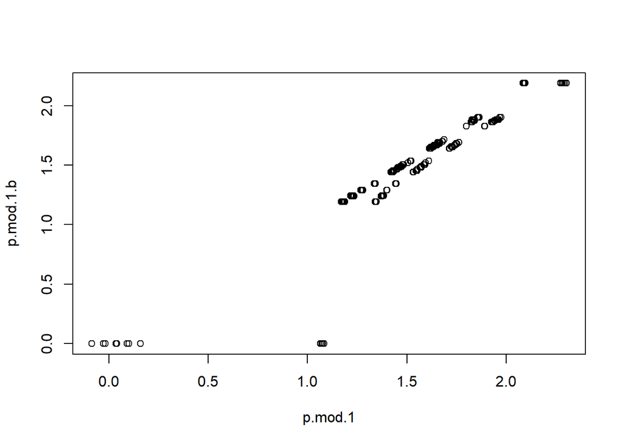

```r
p.mod.1<-lavPredict(r.mod.1)
p.mod.1.b<-lavPredict(r.mod.1.b)

plot(p.mod.1, p.mod.1.b)
```

```r
cor(p.mod.1, p.mod.1.b)
```

```
##           f
## f 0.9769188
```

## Con el score observado

```r
Dp<-data.frame(cbind(D, p.mod.1, p.mod.1.b))
Dp$obs.score<-rowSums(D[,1:9])
Dp$obs.score.b<-rowSums(D[,1:5])
```

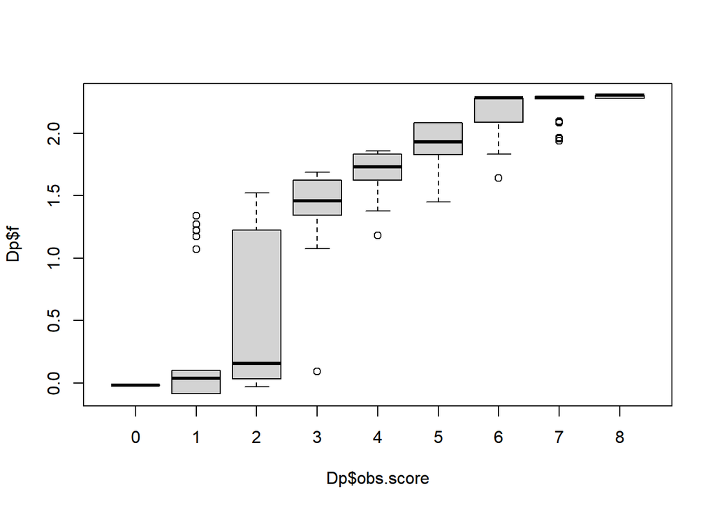

```r
boxplot(Dp$f~Dp$obs.score)
```

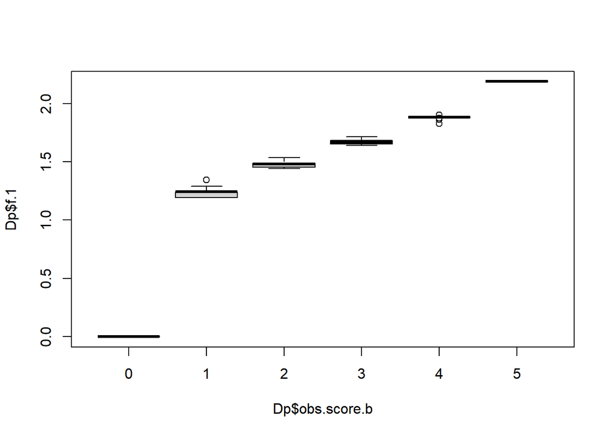

```r
boxplot(Dp$f.1~Dp$obs.score.b)
```

## Confiabilidad

Utilizamos el paquete `semTools` para estimar confiabilidad. Dentro de este paquete vamos a implementar la función `reliability()`. Esta función nos arroja distintos estadísticos. Algunas consideraciones se ponen a continuación:

- Cuando se trata de variables ordinales y equivalencia Tau se sostiene entonces es utilizar $\alpha_o$ (alpha ordinal) es razonable.
- Los omegas utilizan diferente denominador. $\omega_1$ supone que los errores del modelo no están correlacionados. $\omega_2$ considera correlaciones de los errores. $\omega_1$ y $\omega_2$ suponen que la matriz de covarianzas del modelo explica la relación entre los ítems a la perfección. $\omega_3$ es el más conservador y utiliza la matriz de covarianzas observada.
- Cuando el ajuste del modelo es bueno lo más recomendable es utilizar $\omega_3$. Cuando no es así, es mejor utilizar $\omega_{1,2}$ cuando estos son iguales.
- La avevar es la varianza extraída promedio de cada indicador. En el caso del segundo modelo es mucho más alta.

```r
library(semTools)

reliability(r.mod.1)
```

```
##                   f
## alpha     0.5867913
## alpha.ord 0.8347612
## omega     0.6375847
## omega2    0.6375847
## omega3    0.6396948
## avevar    0.5652252
```

```r
reliability(r.mod.1.b)
```

```
##                   f
## alpha     0.8536930
## alpha.ord 0.9731230
## omega     0.8691660
## omega2    0.8691660
## omega3    0.8691324
## avevar    0.8789353
```

# Modelo 2

Suponga que un segundo equipo de investigación pretende medir el mismo fenómeno pero propone un modelo unidimensional de 15 indicadores. Es decir, es una expansión del modelo anterior. A este modelo le vamos a llamar `mod.2` y los resultados los vamos a guardar en el objeto `r.mod.2`

```r
mod.2<-'f =~ V1 + V2 + V3 + V4 + V5 + V6 + V7 + V8 + V9 + V10 + V11 + V12 + V13 + V14 + V15'
r.mod.2<-sem(mod.2, data=D, ordered=T)
```

```r
fitMeasures(r.mod.2, c("cfi.robust", "tli.robust", "rmsea.robust"))
```

```
##   cfi.robust   tli.robust rmsea.robust
##        0.999        0.999        0.012
```

```r
inspect(r.mod.2,what="std")
```

```
## $lambda
##          f
## V1   0.949
## V2   0.944
## V3   0.933
## V4   0.944
## V5   0.920
## V6   0.816
## V7   0.080
## V8   0.032
## V9  -0.019
## V10  0.917
## V11  0.888
## V12  0.803
## V13  0.898
## V14  0.876
## V15  0.783
##
## $theta
##        V1    V2    V3    V4    V5    V6    V7    V8    V9   V10   V11   V12
## V1  0.100
## V2  0.000 0.109
## V3  0.000 0.000 0.129
## V4  0.000 0.000 0.000 0.109
## V5  0.000 0.000 0.000 0.000 0.153
## V6  0.000 0.000 0.000 0.000 0.000 0.335
## V7  0.000 0.000 0.000 0.000 0.000 0.000 0.994
## V8  0.000 0.000 0.000 0.000 0.000 0.000 0.000 0.999
## V9  0.000 0.000 0.000 0.000 0.000 0.000 0.000 0.000 1.000
## V10 0.000 0.000 0.000 0.000 0.000 0.000 0.000 0.000 0.000 0.159
## V11 0.000 0.000 0.000 0.000 0.000 0.000 0.000 0.000 0.000 0.000 0.212
## V12 0.000 0.000 0.000 0.000 0.000 0.000 0.000 0.000 0.000 0.000 0.000 0.356
## V13 0.000 0.000 0.000 0.000 0.000 0.000 0.000 0.000 0.000 0.000 0.000 0.000
## V14 0.000 0.000 0.000 0.000 0.000 0.000 0.000 0.000 0.000 0.000 0.000 0.000
## V15 0.000 0.000 0.000 0.000 0.000 0.000 0.000 0.000 0.000 0.000 0.000 0.000
##       V13   V14   V15
## V1
## V2
## V3
## V4
```

[output cut: 58 more lines]

```
## V1       1
## V2       1
## V3       1
## V4       1
## V5       1
## V6       1
## V7       1
## V8       1
## V9       1
## V10      1
## V11      1
## V12      1
## V13      1
## V14      1
## V15      1
```

## Similitud entre los scores

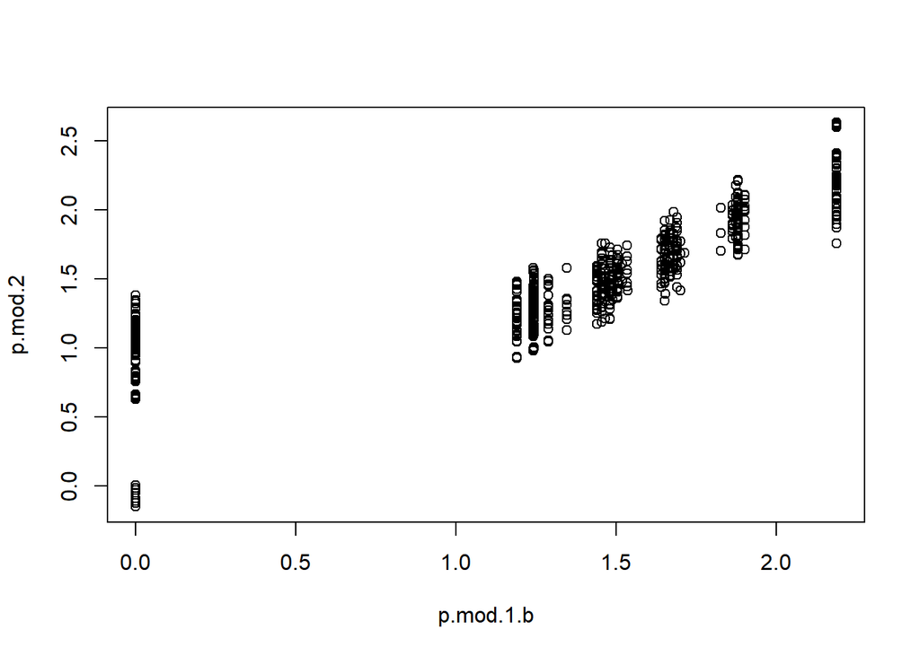

```r
p.mod.2<-lavPredict(r.mod.2)

plot(p.mod.1.b, p.mod.2)
```

```r
cor(p.mod.1.b, p.mod.2)
```

```
##           f
## f 0.8239737
```

```r
Dp$obs.score.2<-rowSums(D[,1:15])
```

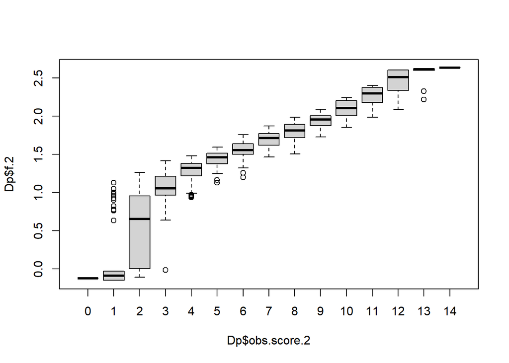

```r
Dp<-data.frame(cbind(Dp, p.mod.2))
boxplot(Dp$f.2~Dp$obs.score.2)
```

## Confiabilidad

Más variables no mejora la confiabilidad. No es el tamaño de datos sino la calidad de información.

```r
reliability(r.mod.1.b)
```

```
##                   f
## alpha     0.8536930
## alpha.ord 0.9731230
## omega     0.8691660
## omega2    0.8691660
## omega3    0.8691324
## avevar    0.8789353
```

```r
reliability(r.mod.2)
```

```
##                   f
## alpha     0.7946411
## alpha.ord 0.9386777
## omega     0.8278371
## omega2    0.8278371
## omega3    0.8289634
## avevar    0.6357990
```

# Modelo 3

El tercer modelo es una expansión del primer modelo que agrega los indicadores V10-V12. Por las simulaciones se sabe que estos indicadores son tienen muy bajo error y no son redundantes (aportan distinta información).

```r
mod.3<-'f =~ V1 + V2 + V3 + V4 + V5 + V10 + V11 + V12'

r.mod.3<-sem(mod.3, data=D, ordered=T)
```

```r
fitMeasures(r.mod.3, c("cfi.robust", "tli.robust", "rmsea.robust"))
```

```
##   cfi.robust   tli.robust rmsea.robust
##        1.000        1.003        0.000
```

```r
inspect(r.mod.3,what="std")
```

```
## $lambda
##         f
## V1  0.951
## V2  0.939
## V3  0.934
## V4  0.944
## V5  0.921
## V10 0.919
## V11 0.889
## V12 0.801
##
## $theta
##        V1    V2    V3    V4    V5   V10   V11   V12
## V1  0.096
## V2  0.000 0.119
## V3  0.000 0.000 0.128
## V4  0.000 0.000 0.000 0.108
## V5  0.000 0.000 0.000 0.000 0.152
## V10 0.000 0.000 0.000 0.000 0.000 0.155
## V11 0.000 0.000 0.000 0.000 0.000 0.000 0.209
## V12 0.000 0.000 0.000 0.000 0.000 0.000 0.000 0.358
##
## $psi
##   f
## f 1
##
## $nu
##     intrcp
## V1       0
## V2       0
## V3       0
## V4       0
## V5       0
## V10      0
## V11      0
## V12      0
##
## $alpha
##   intrcp
## f      0
##
## $tau
##        thrshl
## V1|t1   1.440
## V2|t1   1.972
## V3|t1   1.585
## V4|t1   1.681
## V5|t1   1.530
## V10|t1  1.038
## V11|t1  1.160
## V12|t1  1.078
##
## $delta
##     scales
## V1       1
## V2       1
## V3       1
## V4       1
## V5       1
## V10      1
## V11      1
## V12      1
```

## Son similares los scores

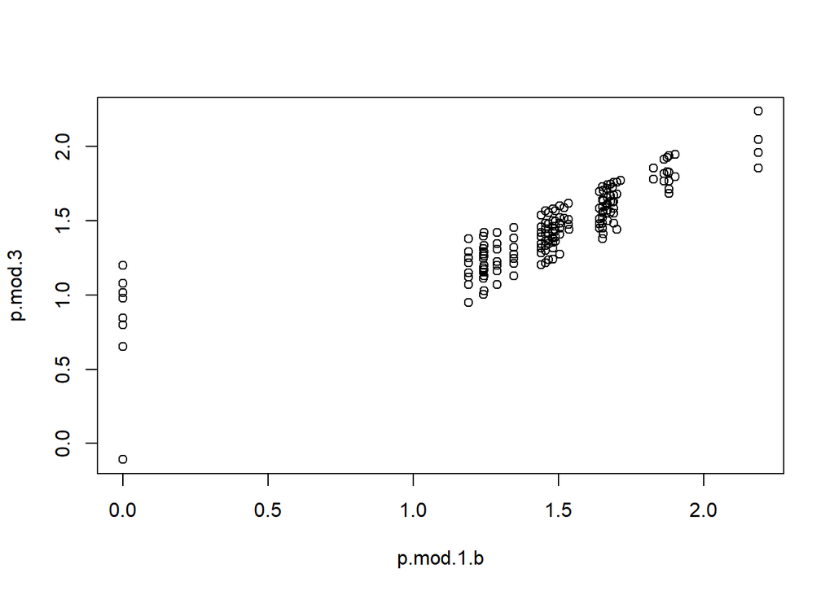

```r
p.mod.3<-lavPredict(r.mod.3)

plot(p.mod.1.b, p.mod.3)
```

```r
cor(p.mod.1.b, p.mod.3)
```

```
##           f
## f 0.8313084
```

```r
Dp$obs.score.3<-rowSums(D[,c(1:5,10:12)])
```

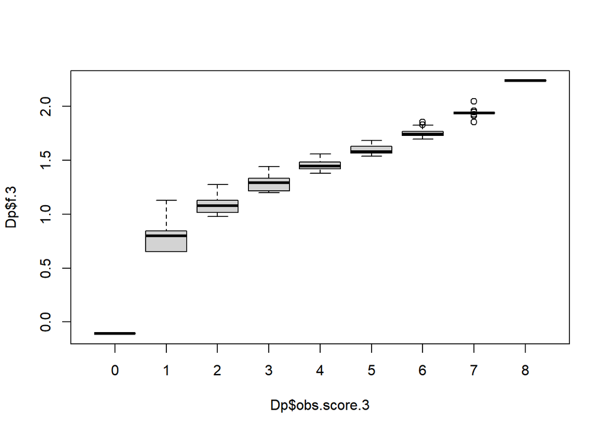

```r
Dp<-data.frame(cbind(Dp, p.mod.3))
boxplot(Dp$f.3~Dp$obs.score.3)
```

## Confiabilidad

Más variables mejora la confiabilidad marginalmente. No es el número de datos sino la calidad de información.

```r
reliability(r.mod.3)
```

```
##                   f
## alpha     0.8699409
## alpha.ord 0.9753556
## omega     0.8892857
## omega2    0.8892857
## omega3    0.8896547
## avevar    0.8343788
```

# Modelo 4: Intercambiando indicadores con la misma información

El modelo 4 usa variables distintas al tercero y el ajuste global es igualmente bueno.

```r
mod.4<-'f =~ V1 + V2 + V3 + V4 + V5 + V13 + V14 + V15'

r.mod.4<-sem(mod.4, data=D, ordered=T)
```

```r
fitMeasures(r.mod.4, c("cfi.robust", "tli.robust", "rmsea.robust"))
```

```
##   cfi.robust   tli.robust rmsea.robust
##        1.000        1.002        0.000
```

```r
inspect(r.mod.4,what="std")
```

```
## $lambda
##         f
## V1  0.944
## V2  0.945
## V3  0.934
## V4  0.944
## V5  0.918
## V13 0.900
## V14 0.875
## V15 0.789
##
## $theta
##        V1    V2    V3    V4    V5   V13   V14   V15
## V1  0.109
## V2  0.000 0.107
## V3  0.000 0.000 0.127
## V4  0.000 0.000 0.000 0.109
## V5  0.000 0.000 0.000 0.000 0.157
## V13 0.000 0.000 0.000 0.000 0.000 0.190
## V14 0.000 0.000 0.000 0.000 0.000 0.000 0.234
## V15 0.000 0.000 0.000 0.000 0.000 0.000 0.000 0.377
##
## $psi
##   f
## f 1
##
## $nu
##     intrcp
## V1       0
## V2       0
## V3       0
## V4       0
## V5       0
## V13      0
## V14      0
## V15      0
##
## $alpha
##   intrcp
## f      0
##
## $tau
##        thrshl
## V1|t1   1.440
## V2|t1   1.972
## V3|t1   1.585
## V4|t1   1.681
## V5|t1   1.530
## V13|t1  1.933
## V14|t1  1.896
## V15|t1  2.046
##
## $delta
##     scales
## V1       1
## V2       1
## V3       1
## V4       1
## V5       1
## V13      1
## V14      1
## V15      1
```

# Error puntual

```r
s.mod.4<-summary(r.mod.4, standardized=TRUE, rsquare=TRUE )
fld.mod.4<-s.mod.4$pe$std.lv[1:8]^2
error.mod.4<-1-fld.mod.4
```

# Elaboración de diagramas de SEM

Para la elaboración de diagramas de SEM existen diferentes paquetes: `lavaanPlot` y `semPlot` son los más populares. En esta ocasión utilizaremos el primero de estos paquetes. Es importante instalar este paquete de la fuente original para asegurarnos que tenemos la versión más nueva del mismo.

```r
#install.packages("devtools")
#devtools::install_github("alishinski/lavaanPlot")
library(lavaanPlot)
```

La función `lavaanPlot()` tiene varias opciones. Si quisieramos solamente el diagrama estructural sin coeficientes basta con indicar el modelo en cuestión.

```r
lavaanPlot(model = r.mod.4)
```

[interactive chart not shown]

Para modificar nuestro diagrama de acuerdo a nuestras necesidades, podemos utilizar las siguientes opciones. Siendo las más importantes `coefs=T` y `stand=T`. Esto para que imprima los valores de los coeficientes estandarizados. Quizá para modelos de SEM donde hay otro tipo de relaciones entre las latentes y las observadas no sea tan útil especificar los coeficientes estandarizados.

```r
lavaanPlot(model = r.mod.4, node_options = list(shape = "box", fontname = "Helvetica"),
            edge_options = list(color = "blue"), coefs = T,
            stand = TRUE, graph_options = list(rankdir = "LR"))
```

[interactive chart not shown]

```r
lavaanPlot(model = r.mod.2, node_options = list(shape = "box", fontname = "Helvetica"),
            edge_options = list(color = "red"), coefs = T,
            stand = TRUE, graph_options = list(rankdir = "LR"))
```

[interactive chart not shown]

# Extras 1: Igualdad de los parámetros

En ocasiones quisiéramos saber si las cargas factoriales de dos parámetros son iguales (¿por qué sería útil saber esto?). Para ello podemos hacer un test formal de Wald. La función para hacerlo es `lavTestWald()`. Está función nos permite hacer una prueba de diferencia entre parámetros, es la misma que se usa en regresión. ¿Qué desventajas podría tener esta prueba? ¿Qué pasa si tiene una muestra pequeña o grande?

```r
mod.1.e<-'f =~ V1 + b2*V2 + b3*V3 + V4 + V5 + V6 + V7 + V8 + b9*V9'
r.mod.1.e<-sem(mod.1.e, data=D, ordered=T)
summary(r.mod.1.e)
```

```
## lavaan 0.6.16 ended normally after 16 iterations
##
##   Estimator                                       DWLS
##   Optimization method                           NLMINB
##   Number of model parameters                        18
##
##   Number of observations                         10000
##
## Model Test User Model:
##                                               Standard      Scaled
##   Test Statistic                                 9.568      18.512
##   Degrees of freedom                                27          27
##   P-value (Chi-square)                           0.999       0.887
##   Scaling correction factor                                  0.574
##   Shift parameter                                            1.854
##     simple second-order correction
##
## Parameter Estimates:
##
##   Standard errors                           Robust.sem
##   Information                                 Expected
##   Information saturated (h1) model        Unstructured
##
## Latent Variables:
##                    Estimate  Std.Err  z-value  P(>|z|)
##   f =~
##     V1                1.000
##     V2        (b2)    0.998    0.011   88.128    0.000
##     V3        (b3)    0.991    0.009  107.674    0.000
##     V4                1.001    0.009  110.110    0.000
##     V5                0.975    0.009  103.759    0.000
##     V6                0.875    0.016   53.736    0.000
##     V7                0.074    0.029    2.503    0.012
##     V8                0.037    0.028    1.323    0.186
##     V9        (b9)   -0.042    0.028   -1.501    0.133
##
## Intercepts:
##                    Estimate  Std.Err  z-value  P(>|z|)
##    .V1                0.000
##    .V2                0.000
```

[output cut: 30 more lines]

```
##    .V8                0.999
##    .V9                0.998
##     f                 0.892    0.011   79.659    0.000
##
## Scales y*:
##                    Estimate  Std.Err  z-value  P(>|z|)
##     V1                1.000
##     V2                1.000
##     V3                1.000
##     V4                1.000
##     V5                1.000
##     V6                1.000
##     V7                1.000
##     V8                1.000
##     V9                1.000
```

```r
lavTestWald(r.mod.1.e, constraints = c("b2 == b3"))
```

```
## $stat
## [1] 0.3716824
##
## $df
## [1] 1
##
## $p.value
## [1] 0.5420887
##
## $se
## [1] "robust.sem"
```

```r
lavTestWald(r.mod.1.e, constraints = c("b2 == b9"))
```

```
## $stat
## [1] 1155.532
##
## $df
## [1] 1
##
## $p.value
## [1] 0
##
## $se
## [1] "robust.sem"
```

# Extras 2: Fijando parámetros

- Razón 1: Muchos modelos de medición descansan en la hipótesis de igualdad de contribuciones/pesos/importancia de las variables de interés. Hicimos notar que en alta confiabilidad ($\omega>.8$) no debe preocuparnos tanto que no haya igualdad exacta en cargas factoriales. Es posible, sin embargo, poner a prueba dicha hipótesis. Esto puede hacerse de varias maneras en `lavaan`. Por ejemplo, imponiendo un valor fijo a cada variable.
- Razón 2: En ocasiones es necesario fijar algún parámetro para poder identificar el modelo. En la mayoría de los casos se sugiere utilizar “1” porque es reflejo de una aspiración (que el indicador tiene nulo error). Sin embargo, fijar parámetros depende de la información que tengamos del modelo de medición en cuestión.

```r
mod.1.f<-'f =~ 1*V1 + 1*V2 + 1*V3 + V4 + V5 + V6 + 1*V7 + 1*V8 + 1*V9'
r.mod.1.f<-sem(mod.1.f, data=D, ordered=T)
summary(r.mod.1.f)
```

```
## lavaan 0.6.16 ended normally after 11 iterations
##
##   Estimator                                       DWLS
##   Optimization method                           NLMINB
##   Number of model parameters                        13
##
##   Number of observations                         10000
##
## Model Test User Model:
##                                                Standard      Scaled
##   Test Statistic                              11730.481    9403.754
##   Degrees of freedom                                 32          32
##   P-value (Chi-square)                            0.000       0.000
##   Scaling correction factor                                   1.249
##   Shift parameter                                             9.929
##     simple second-order correction
##
## Parameter Estimates:
##
##   Standard errors                           Robust.sem
##   Information                                 Expected
##   Information saturated (h1) model        Unstructured
##
## Latent Variables:
##                    Estimate  Std.Err  z-value  P(>|z|)
##   f =~
##     V1                1.000
##     V2                1.000
##     V3                1.000
##     V4                1.326    0.011  117.521    0.000
##     V5                1.238    0.012  107.417    0.000
##     V6                1.047    0.019   55.267    0.000
##     V7                1.000
##     V8                1.000
##     V9                1.000
##
## Intercepts:
##                    Estimate  Std.Err  z-value  P(>|z|)
##    .V1                0.000
##    .V2                0.000
```

[output cut: 30 more lines]

```
##    .V8                0.416
##    .V9                0.416
##     f                 0.584    0.006   93.405    0.000
##
## Scales y*:
##                    Estimate  Std.Err  z-value  P(>|z|)
##     V1                1.000
##     V2                1.000
##     V3                1.000
##     V4                1.000
##     V5                1.000
##     V6                1.000
##     V7                1.000
##     V8                1.000
##     V9                1.000
```

## Confiabilidad bajo igualdad de parámetros

Con la función `reliability()` calculamos confiabilidad. Esto es lo que se podría obtener en caso de que V7-V9 tuvieran cargas factoriales igual a 1. Esto es sospechoso porque ya sabíamos que dichas variables tienen alto erro de medición. ¿Es un buen modelo?

```r
reliability(r.mod.1.f)
```

```
##                   f
## alpha     0.5867913
## alpha.ord 0.8347612
## omega     0.8247231
## omega2    0.8247231
## omega3    1.3743646
## avevar    0.6739781
```

Veamos el ajuste global de este modelo con la función `fitMeasures()`. El modelo es muy malo. La igualdad de parámetros es una ilusión, no hay forma de incorporarla artificialmente a los datos.

```r
fitMeasures(r.mod.1.f, c("cfi.robust", "tli.robust", "rmsea.robust"))
```

```
##   cfi.robust   tli.robust rmsea.robust
##        0.000       -0.469        0.575
```

# Extras 3: Comparación de ajuste global de modelos

¿Es entonces posible fijar los parámetros sin ningún tipo de penalización? **No**. Esto se puede comprobar fácilmente comparando el ajuste global de los tres modelos: El original, el modelo al que asignamos etiquetas a algunos parámetros y el modelo con restricciones en las cargas factoriales.

La comparación se hace fácilmente con la función `compareFit()` del paquete `semTools`. Una vez implementada la función, lo que sigue es extraer el resumen de los resultados. Los modelos se ordenan de mejor a peor ajuste. Vemos que el modelo `r.mod.1.f` es el peor. La prueba $\chi^2$ confirma el resultado. Cuando $p<.05$ se rechaza el modelo actual.

```r
comp<-compareFit(r.mod.1.f, r.mod.1.e, r.mod.1)
summary(comp)
```

```
## ################### Nested Model Comparison #########################
##
## Scaled Chi-Squared Difference Test (method = "satorra.2000")
##
## lavaan NOTE:
##     The "Chisq" column contains standard test statistics, not the
##     robust test that should be reported per model. A robust difference
##     test is a function of two standard (not robust) statistics.
##
##           Df AIC BIC      Chisq Chisq diff Df diff Pr(>Chisq)
## r.mod.1.e 27             9.5684
## r.mod.1   27             9.5684        0.0       0
## r.mod.1.f 32         11730.4809     4161.7       5  < 2.2e-16 ***
## ---
## Signif. codes:  0 '***' 0.001 '**' 0.01 '*' 0.05 '.' 0.1 ' ' 1
##
## ####################### Model Fit Indices ###########################
##           chisq.scaled df.scaled pvalue.scaled rmsea.robust cfi.robust
## r.mod.1.e      18.512†        27          .887        .000†     1.000†
## r.mod.1        18.512†        27          .887        .000†     1.000†
## r.mod.1.f    9403.754         32          .000        .575       .000
##           tli.robust  srmr
## r.mod.1.e     1.006† .013†
## r.mod.1       1.006† .013†
## r.mod.1.f    -0.469  .440
##
## ################## Differences in Fit Indices #######################
##                     df.scaled rmsea.robust cfi.robust tli.robust  srmr
## r.mod.1 - r.mod.1.e         0        0.000          0      0.000 0.000
## r.mod.1.f - r.mod.1         5        0.575         -1     -1.474 0.428
```

# Extras 4: ICLUST beta

Si quisiéramos explorar las relaciones entre los indicadores sin comprometernos a un CFA, podemos utilizar el Iclust de William Revelle que sirve para calcular $\beta$. Si lo aplicamos a la primera propuesta de nueve indicadores tendríamos que llamar al paquete `psych()` y utilizar la función `ICLUST()`.

```r
library(psych)
#install.packages("psychTools")

Beta<-ICLUST(D[,1:9])
```

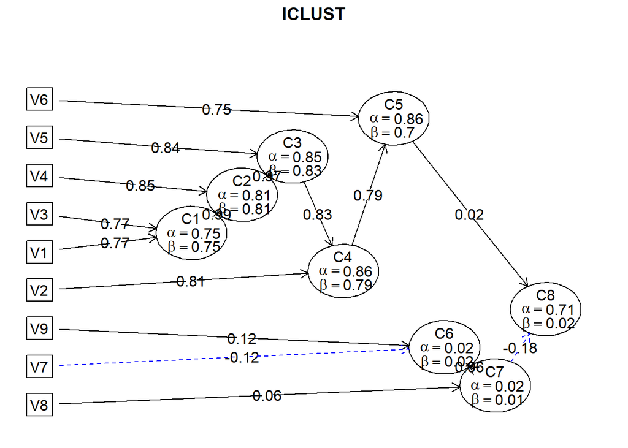

```r
Beta
```

```
## ICLUST (Item Cluster Analysis)
## Call: iclust(r.mat = r.mat, nclusters = nclusters, alpha = alpha, beta = beta,
##     beta.size = beta.size, alpha.size = alpha.size, correct = correct,
##     correct.cluster = correct.cluster, reverse = reverse, beta.min = beta.min,
##     output = output, digits = digits, labels = labels, cut = cut,
##     n.iterations = n.iterations, title = title, plot = plot,
##     weighted = weighted, cor.gen = cor.gen, SMC = SMC, purify = purify,
##     diagonal = diagonal)
##
## Purified Alpha:
## [1] 0.71
##
## G6* reliability:
## [1] 0.92
##
## Original Beta:
## [1] 0.023
##
## Cluster size:
## [1] 9
##
## Item by Cluster Structure matrix:
##    [,1]
## V1  0.75
## V2  0.68
## V3  0.75
## V4  0.76
## V5  0.72
## V6  0.56
## V7  0.03
## V8  0.01
## V9 -0.02
##
## With Sums of squares of:
## [1] 3
##
## Purified scale intercorrelations
##  reliabilities on diagonal
##  correlations corrected for attenuation above diagonal:
##      [,1]
## [1,] 0.71
##
## Cluster fit =  0.73   Pattern fit =  1  RMSR =  0.02
```